# Functionals

### Functionals

- We have already seen closures- a function that takes a function as an argument and returns another function. Now lets look at functionals- functions that take functions as inputs and return vectors

```r
# here is a simple functional

randomise <- function(f) f(runif(1e3))
randomise(mean)
```

```
## [1] 0.5213956
```

```r
randomise(sum)
```

```
## [1] 508.8911
```

- three common functionals are lapply(), apply(), tapply().
- functionals commonly used to avoid loops in R. Loops can be slow, but the real downside is that they are not very expressive. Functionals make it very clear what you are trying to achieve. Reduce bugs by better communicating intent.

### lapply()

```r
# lets make lapply2()
# it does the same as lapply, just not written in C
lapply2 <- function(x, f, ...){
  out <- vector("list", length(x))
  for (i in seq_along(x)){
    out[i] <- f(x[[i]], ...)
  }
  out
}
```

- lapply is super handy to apply functions over columns in data frames e.g. lapply(mtcars, class), or mtcars[] <- lapply(mtcars, function(f) x / mean(x))
- the peices of x are always supplied as the first argument to f. if you want to vary different argument, use anonymous function

```r
trims <- c(0, 0.1, 0.2, 0.5)
x <- rcauchy(1000)
unlist(lapply(trims, function(trim) mean(x, trim = trim)))
```

```
## [1] -0.342385857  0.006376529  0.030444614  0.018187486
```

### Looping patterns

- three basic ways to loop: loop over elements: for x in xs, loop over numeric indices: for (i in seq_along(xs)) and loop over names: for (nm in names(xs))
- first way bad as leads to inefficient ways of saving output eg

```r
# this slow- R makes a copy of res at every iteration
# when vector gets extended
xs <- runif(1e3)
res <- c()
for (x in xs){
  res <- c(res, sqrt(x))
}

# this is better
res <- numeric(length(xs))
for (i in seq_along(xs)){
  res[i] <- sqrt(xs[i])
}
```

- there are three basic ways to use lapply()

```r
# usually use the first form as lapply() takes care of saving the output
# however if need the position or name of elemnt use the other forms
lapply(xs, function(x) {})
lapply(seq_along(xs), function(i) {})
lapply(names(xs), function(nm) {})
```

### Friends of lapply()

- sapply() and vapply() - variants of lapply that create vectors, matrices and arrays instead of lists
- Map() and mapply() which iterate over multiple input data structures
- mclapply() and mcMap() - parralel versions of lapply() and Map()
- rollapply() writes new functions to solve a probelsm

### sapply and vapply

- very simialr to lapply(), except simplify output to produce atomic vector. sapply() guesses, vapply() takes argument specifying output type. sapply() good for interactive, vapply() more verbose and useful for use inside other functions

```r
sapply(mtcars, is.numeric)
```

```
##  mpg  cyl disp   hp drat   wt qsec   vs   am gear carb
## TRUE TRUE TRUE TRUE TRUE TRUE TRUE TRUE TRUE TRUE TRUE
```

```r
vapply(mtcars, is.numeric, logical(1))
```

```
##  mpg  cyl disp   hp drat   wt qsec   vs   am gear carb
## TRUE TRUE TRUE TRUE TRUE TRUE TRUE TRUE TRUE TRUE TRUE
```

```r
# hmm
sapply(list(), is.numeric)
```

```
## list()
```

```r
# correct
vapply(list(), is.numeric, logical(1))
```

```
## logical(0)
```

- sapply is a thin wrapper around lapply(), that transforms to vector at final step. vapply() assigns results to a vector (or matrix) of appropriate type instead of as a list.

```r
# sapply does this
sapply2 <- function(x, f, ...){
  res <- lapply2(x, f, ...)
  simplify2array(res)
}

# vapply does this
vapply2 <- function(x, f, f.value, ...){
  out <- matrix(rep(f.value, length(x)), nrow = length(x))
  for (i in seq_along(x)){
    res <- f(x[i], ...)
    stopifnot(
      length(res) == length(f.value),
      typeof(res) == typeof(f.value)
    )
    out[i, ] <- res
  }
  out
}
```

### Multiple inputs: Map and mapply()

- with lapply(), only one argument to the functions varies, the others are fixed. This makes it poorly suited for some problems, eg weighted means when you have two lists- observations and weights

```r
# obs
xs <- replicate(5, runif(10), simplify = FALSE)
# weights
ws <- replicate(5, rpois(10, 5) + 1, simplify = FALSE)

# unweighted means easy
unlist(lapply(xs, mean))
```

```
## [1] 0.4421659 0.4949479 0.4887713 0.5552102 0.4798022
```

```r
# weighted mean messy with lapply()
unlist(lapply(seq_along(xs), function(i){
  weighted.mean(xs[[i]], ws[[i]])
}))
```

```
## [1] 0.4737302 0.4819125 0.4863886 0.5644349 0.4789990
```

```r
# so use Map instead
unlist(Map(weighted.mean, xs, ws))
```

```
## [1] 0.4737302 0.4819125 0.4863886 0.5644349 0.4789990
```

```r
# this is equivalent to
stopifnot(length(xs) == length(ws))
out <- vector("list", length(xs))
for (i in seq_along(xs)){
  out[[i]] <- weighted.mean(xs[[i]], ws[[i]])
}
```

### Rolling Computations

- may want to perform rollying calculations. do this in general- same function to do rolling mean or rolling median

```r
rollapply <- function(x, n, f, ...){
  out <- rep(NA, length(x))

  # trunc just removes anything after decimal
  offset <- trunc(n / 2)
  locs <- (offset + 1):(length(x) - n + offset + 1)
  num <- vapply(
    locs,
    function(i) f(x[(i - offset):(i + offset)], ...),
    numeric(1)
  )
  # first offset amount will be NA's
  c(rep(NA, offset), num)
}

set.seed(123)
x <- seq(1, 3, length(1e2)) + rt(1e2, df = 2) / 3
```

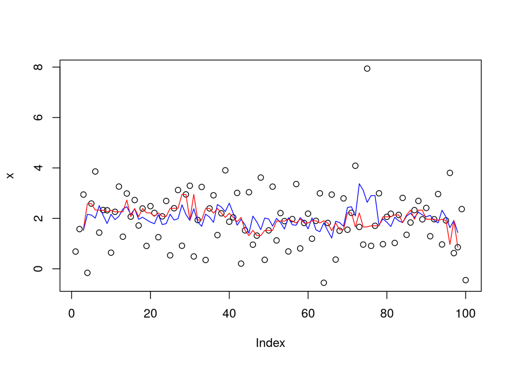

```r
plot(x)
lines(rollapply(x, 5, mean), col = 'blue')
lines(rollapply(x, 5, median), col = 'red')
```

- the zoo::rollapply() function does the same thing. Most useful!!

### Parrellisation

- use mclapply() and mcMap()

```r
library(parallel)
unlist(mclapply(1:10, sqrt, mc.cores = 4))
```

```
##  [1] 1.000000 1.414214 1.732051 2.000000 2.236068 2.449490 2.645751
##  [8] 2.828427 3.000000 3.162278
```

```r
unlist(mcMap(weighted.mean, 1:10, 10:20, mc.cores = 4))
```

```
##  [1]  1  2  3  4  5  6  7  8  9 10  1
```

- also check out pvec()

### Manipulating matrices and data frames

- functionals can be used to eliminate loops in common data manipulation tasks. for matrices we have: apply(), sweep() and outer()
- tapply() summarises a vector by groups defined by another vector
- plyr package generalises tapply() (but dplyr better!!)

```r
# apply works on matrices

# margin argument specifies rows (1) or columns (2)
a <- matrix(1:20, nrow = 5)
apply(a, 1, mean)
```

```
## [1]  8.5  9.5 10.5 11.5 12.5
```

```r
apply(a, 2, mean)
```

```
## [1]  3  8 13 18
```

- note that apply() has no simplify option, also is not idempotent (plyr::aaply() is though)
- sweep() allows you to sweep summary statistic

```r
# here we use sweep to standardise an array
x <- matrix(rnorm(20, 0, 10), nrow = 4)

# step 1 - sweep to subtract min value in each row from row
x1 <- sweep(x, 1, apply(x, 1, min), `-`)
# step 2 - sweep to divide by the max value of each row
x2 <- sweep(x1, 1, apply(x1, 1, max), `/`)

x
```

```
##           [,1]       [,2]      [,3]        [,4]      [,5]
## [1,]  9.020247 -13.306950 -2.919208   0.7499953  3.955099
## [2,]  6.403630  -5.922097 -8.241094 -21.4041848  8.864217
## [3,]  9.512089  18.010509 12.162502  14.7097224 12.010426
## [4,] -5.991232  10.553386  2.197284  -8.3776761 13.168057
```

```r
x1
```

```
##           [,1]     [,2]      [,3]      [,4]      [,5]
## [1,] 22.327197  0.00000 10.387742 14.056945 17.262049
## [2,] 27.807815 15.48209 13.163091  0.000000 30.268402
## [3,]  0.000000  8.49842  2.650414  5.197634  2.498337
## [4,]  2.386444 18.93106 10.574960  0.000000 21.545733
```

```r
x2
```

```
##           [,1]      [,2]      [,3]      [,4]      [,5]
## [1,] 1.0000000 0.0000000 0.4652506 0.6295884 0.7731400
## [2,] 0.9187077 0.5114934 0.4348790 0.0000000 1.0000000
## [3,] 0.0000000 1.0000000 0.3118713 0.6116000 0.2939766
## [4,] 0.1107618 0.8786455 0.4908146 0.0000000 1.0000000
```

- outer() takes multiple vector inputs and creates a matrix or array output where the input function is rung over every combination of the inputs

```r
# create a times table
outer(1:3, 1:10, "*")
```

```
##      [,1] [,2] [,3] [,4] [,5] [,6] [,7] [,8] [,9] [,10]
## [1,]    1    2    3    4    5    6    7    8    9    10
## [2,]    2    4    6    8   10   12   14   16   18    20
## [3,]    3    6    9   12   15   18   21   24   27    30
```

### Group apply

- tapply() can be throught of as a generalisation to apply() that allows for ragged arrays with different numbers of columns. Often needed when summarising data sets:

```r
pulse <- round(rnorm(22, 70, 10/3)) + rep(c(0,5), c(10, 12))
group <- rep(c("A", "B"), c(10, 12))

tapply(pulse, group, length)
```

```
##  A  B
## 10 12
```

```r
tapply(pulse, group, mean)
```

```
##        A        B
## 69.00000 75.41667
```

```r
# tapply() splits then applies

split(pulse, group)
```

```
## $A
##  [1] 69 72 63 70 73 69 67 71 71 65
##
## $B
##  [1] 71 79 74 69 77 73 78 78 74 71 83 78
```

```r
# this tapply2() function is equivalent to tapply()
tapply2 <- function(x, group, f, ..., simplify = TRUE){
  pieces <- split(x, group)
  sapply(pieces, f, simplify = simplify)
}

tapply2(pulse, group, length)
```

```
##  A  B
## 10 12
```

### plyr

- plyr is useful for split-apply-combine. read about it in the paper. Im not sure if dplyr fully supercedes plyr, or if there is still use…

### Manipulating Lists

- we do this with Map(), Reduce() and Filter() to alter, subset and collapse lists

```r
# we have already seen Map, lets have a look at Reduce()

Reduce(sum, 1:3) # sum(sum(1, 2), 3)
```

```
## [1] 6
```

```r
# it does this (although real reduce far more complex)
Reduce2 <- function(f, x){
  out <- x[[1]]
  for(i in seq(2, length(x))){
    out <- f(out, x[[i]])
  }
  out
}

# Reduce is an elegant way to extend functions that deal with two inputs to a function
# that can deal with any number of inputs.

l <- replicate(5, sample(1:10, 15, replace = T), simplify = F)
str(l)
```

```
## List of 5
##  $ : int [1:15] 8 10 1 10 9 8 4 1 4 3 ...
##  $ : int [1:15] 5 8 2 3 10 8 9 5 6 8 ...
##  $ : int [1:15] 1 4 7 8 10 5 6 8 9 10 ...
##  $ : int [1:15] 2 8 3 1 10 2 7 2 1 6 ...
##  $ : int [1:15] 3 5 5 8 8 9 9 10 6 6 ...
```

```r
# what is the intersect between all in the list?
Reduce(intersect, l)
```

```
## [1]  8 10  1  9
```

### Predicate functionals

- a predicate is a function that returns a single TRUE or FALSE. a predicate FUNCTIONAL applies a predicate to each element of a list or data frame. There are three useful predicate functionals in base R: Filter(), Find() and Position()
- Filter() slects elements that only match predicate
- Find() returns the first element that matches predicate (or last if right = TRUE)
- Position() returns the position of the first element (or last if right = TRUE)

```r
# lets make a custom where() predicate

where <- function(f, x) {
  vapply(x, f, logical(1))
}

df <- data.frame(x = 13, y = c('a', 'b', 'c'))
where(is.factor, df)
```

```
##     x     y
## FALSE  TRUE
```

```r
str(Filter(is.factor, df))
```

```
## 'data.frame':    3 obs. of  1 variable:
##  $ y: Factor w/ 3 levels "a","b","c": 1 2 3
```

```r
str(Find(is.factor, df))
```

```
##  Factor w/ 3 levels "a","b","c": 1 2 3
```

```r
Position(is.factor, df)
```

```
## [1] 2
```